# P2P Loans: Prosper Dataset

## Preliminary Wrangling

For this project I have selected a dataset from Prosper Loan, a California-based FinTech which facilitates peer-to-peer loans. Prospective borrowers request personal loans through Prosper, with individual or institutional investors choosing who to fund. The loans, worth anywhere from \$2,000 to \\$40,000, are distributed through Prosper. Prosper also collects and allocates payments and interests from borrowers to lenders. Investors make lending decisions based on a borrower's credit score, rating, and history, as well as the category of the loan ([source](https://en.wikipedia.org/wiki/Prosper_Marketplace)). As someone also working in the FinTech industry, in mobile banking, I am excited to learn more about a different aspect of the sector.

The dataset itself was provided through Udacity's Data Analyst Nanodegree program, but similar historical data can also be obtained directly through Prosper via an API, as long as the requester has a valid Prosper account ([source](https://prosper.zendesk.com/hc/en-us/articles/210013083-Where-can-I-download-Prosper-loan-data-)). Documentation for the dataset is available through [Udacity](https://docs.google.com/spreadsheets/d/1gDyi_L4UvIrLTEC6Wri5nbaMmkGmLQBk-Yx3z0XDEtI/edit#gid=0) or [Prosper](https://www.prosper.com/Downloads/Services/Documentation/ProsperDataExport_Details.html).

```python
# import all packages and set plots to be embedded inline
import numpy as np
import pandas as pd
import matplotlib.pyplot as plt
from matplotlib.colors import ListedColormap
import seaborn as sns
import warnings

%matplotlib inline

# suppress warnings
warnings.simplefilter('ignore')
```

To better understand each dataset, I will first view the first few lines of code using .head(). I can then learn more about the dataset's size and datatypes using .shape and .dtypes. To determine what I will need to clean, I can use sum(df.duplicated()) to check if any duplicate rows exist and pd.isnull(df).sum() to see how many missing values are present. In doing so, I can learn more relevant technical and content-specific information about the dataset. My main findings will be summarized below.

```python
# load dataset and view dataframe
prosper = pd.read_csv(r'C:\Users\t_gas\Desktop\Data Portfolio\Udacity\Communicate Data\prosperLoanData.csv')
prosper.head()
```

|  | ListingKey | ListingNumber | ListingCreationDate | CreditGrade | Term | LoanStatus | ClosedDate | BorrowerAPR | BorrowerRate | LenderYield | ... | LP_ServiceFees | LP_CollectionFees | LP_GrossPrincipalLoss | LP_NetPrincipalLoss | LP_NonPrincipalRecoverypayments | PercentFunded | Recommendations | InvestmentFromFriendsCount | InvestmentFromFriendsAmount | Investors |
| --- | --- | --- | --- | --- | --- | --- | --- | --- | --- | --- | --- | --- | --- | --- | --- | --- | --- | --- | --- | --- | --- |
| 0 | 1021339766868145413AB3B | 193129 | 2007-08-26 19:09:29.263000000 | C | 36 | Completed | 2009-08-14 00:00:00 | 0.16516 | 0.1580 | 0.1380 | ... | -133.18 | 0.0 | 0.0 | 0.0 | 0.0 | 1.0 | 0 | 0 | 0.0 | 258 |
| 1 | 10273602499503308B223C1 | 1209647 | 2014-02-27 08:28:07.900000000 | NaN | 36 | Current | NaN | 0.12016 | 0.0920 | 0.0820 | ... | 0.00 | 0.0 | 0.0 | 0.0 | 0.0 | 1.0 | 0 | 0 | 0.0 | 1 |
| 2 | 0EE9337825851032864889A | 81716 | 2007-01-05 15:00:47.090000000 | HR | 36 | Completed | 2009-12-17 00:00:00 | 0.28269 | 0.2750 | 0.2400 | ... | -24.20 | 0.0 | 0.0 | 0.0 | 0.0 | 1.0 | 0 | 0 | 0.0 | 41 |
| 3 | 0EF5356002482715299901A | 658116 | 2012-10-22 11:02:35.010000000 | NaN | 36 | Current | NaN | 0.12528 | 0.0974 | 0.0874 | ... | -108.01 | 0.0 | 0.0 | 0.0 | 0.0 | 1.0 | 0 | 0 | 0.0 | 158 |
| 4 | 0F023589499656230C5E3E2 | 909464 | 2013-09-14 18:38:39.097000000 | NaN | 36 | Current | NaN | 0.24614 | 0.2085 | 0.1985 | ... | -60.27 | 0.0 | 0.0 | 0.0 | 0.0 | 1.0 | 0 | 0 | 0.0 | 20 |

5 rows × 81 columns

```python
# view size
prosper.shape
```

```
(113937, 81)
```

Because this dataset is so large, I will override panda's default output settings.

```python
pd.set_option('display.max_rows', 120)
```

```python
# check datatypes
prosper.dtypes
```

```
ListingKey                              object
ListingNumber                            int64
ListingCreationDate                     object
CreditGrade                             object
Term                                     int64
LoanStatus                              object
ClosedDate                              object
BorrowerAPR                            float64
BorrowerRate                           float64
LenderYield                            float64
EstimatedEffectiveYield                float64
EstimatedLoss                          float64
EstimatedReturn                        float64
ProsperRating (numeric)                float64
ProsperRating (Alpha)                   object
ProsperScore                           float64
ListingCategory (numeric)                int64
BorrowerState                           object
Occupation                              object
EmploymentStatus                        object
EmploymentStatusDuration               float64
IsBorrowerHomeowner                       bool
CurrentlyInGroup                          bool
GroupKey                                object
DateCreditPulled                        object
CreditScoreRangeLower                  float64
CreditScoreRangeUpper                  float64
FirstRecordedCreditLine                 object
CurrentCreditLines                     float64
OpenCreditLines                        float64
TotalCreditLinespast7years             float64
OpenRevolvingAccounts                    int64
OpenRevolvingMonthlyPayment            float64
InquiriesLast6Months                   float64
TotalInquiries                         float64
CurrentDelinquencies                   float64
AmountDelinquent                       float64
DelinquenciesLast7Years                float64
PublicRecordsLast10Years               float64
PublicRecordsLast12Months              float64
```

[output cut: 27 more lines]

```
MonthlyLoanPayment                     float64
LP_CustomerPayments                    float64
LP_CustomerPrincipalPayments           float64
LP_InterestandFees                     float64
LP_ServiceFees                         float64
LP_CollectionFees                      float64
LP_GrossPrincipalLoss                  float64
LP_NetPrincipalLoss                    float64
LP_NonPrincipalRecoverypayments        float64
PercentFunded                          float64
Recommendations                          int64
InvestmentFromFriendsCount               int64
InvestmentFromFriendsAmount            float64
Investors                                int64
dtype: object
```

```python
# check for duplicates
sum(prosper.duplicated())
```

```
0
```

```python
# check for null values
pd.isnull(prosper).sum()
```

```
ListingKey                                  0
ListingNumber                               0
ListingCreationDate                         0
CreditGrade                             84984
Term                                        0
LoanStatus                                  0
ClosedDate                              58848
BorrowerAPR                                25
BorrowerRate                                0
LenderYield                                 0
EstimatedEffectiveYield                 29084
EstimatedLoss                           29084
EstimatedReturn                         29084
ProsperRating (numeric)                 29084
ProsperRating (Alpha)                   29084
ProsperScore                            29084
ListingCategory (numeric)                   0
BorrowerState                            5515
Occupation                               3588
EmploymentStatus                         2255
EmploymentStatusDuration                 7625
IsBorrowerHomeowner                         0
CurrentlyInGroup                            0
GroupKey                               100596
DateCreditPulled                            0
CreditScoreRangeLower                     591
CreditScoreRangeUpper                     591
FirstRecordedCreditLine                   697
CurrentCreditLines                       7604
OpenCreditLines                          7604
TotalCreditLinespast7years                697
OpenRevolvingAccounts                       0
OpenRevolvingMonthlyPayment                 0
InquiriesLast6Months                      697
TotalInquiries                           1159
CurrentDelinquencies                      697
AmountDelinquent                         7622
DelinquenciesLast7Years                   990
PublicRecordsLast10Years                  697
PublicRecordsLast12Months                7604
```

[output cut: 27 more lines]

```
MonthlyLoanPayment                          0
LP_CustomerPayments                         0
LP_CustomerPrincipalPayments                0
LP_InterestandFees                          0
LP_ServiceFees                              0
LP_CollectionFees                           0
LP_GrossPrincipalLoss                       0
LP_NetPrincipalLoss                         0
LP_NonPrincipalRecoverypayments             0
PercentFunded                               0
Recommendations                             0
InvestmentFromFriendsCount                  0
InvestmentFromFriendsAmount                 0
Investors                                   0
dtype: int64
```

### What is the structure of your dataset?

Wow, this dataset is pretty large! It contains 113,937 rows and 81 columns. Luckily, no rows have been duplicated and it seems like all columns have been assigned the correct datatype. However, many columns are missing data - anywhere from 25 ('BorrowerAPR') to over 100,000 ('GroupKey'). Normally, I would also now view some statistical information using .describe(), but given the large size of the dataset I want to first think deeper about how to strategically investigate some key features.

### What is the main feature of interest in your dataset?

There's a lot of information available in this dataset - almost too much! After re-reading through the documentation, I've decided to focus on the borrower rate. I want to explore borrowers' economic demographics in relation to this rate. My assumption is that borrowers in better economic standing receive more favorable interest rates as they are considered by investors to be less risky. But is my assumption true?

### What features in the dataset do you think will help support your investigation into your feature(s) of interest?

To answer these questions, I will need to create a smaller dataset containing relevant information about the borrower's financial health (e.g. 'Occupation', 'EmploymentStatus', 'EmploymentStatusDuration', 'IsBorrowerHomeowner', 'CreditScoreRangeLower', 'CreditScoreRangeUpper', 'CurrentCreditLines', 'OpenCreditLines', 'DebtToIncomeRatio', 'IncomeRange', 'IncomeVerifiable', and 'StatedMonthlyIncome').

```python
borrower =  prosper[['ListingKey', 'BorrowerRate', 'Occupation', 'EmploymentStatus',
                     'EmploymentStatusDuration', 'IsBorrowerHomeowner','CreditScoreRangeLower',
                     'CreditScoreRangeUpper', 'CurrentCreditLines', 'OpenCreditLines', 'DebtToIncomeRatio',
                     'IncomeRange','IncomeVerifiable', 'StatedMonthlyIncome']]
```

## Univariate Exploration

I'll begin my investigation with some univariate plots, first looking at my main feature, the borrower rate, and then exploring other financial variables.

```python
# set plot color palette
col_list = ["warm grey", "gunmetal", "dusky blue","cool blue", "deep teal","viridian", "twilight blue"]
col_list_palette = sns.xkcd_palette(col_list)
sns.set_palette(col_list_palette)
base_color = sns.color_palette()[0]
```

Before diving into EDA, I want to again check for null values as well as examine the dataset's summary statistics.

```python
borrower.info()
```

```
<class 'pandas.core.frame.DataFrame'>
RangeIndex: 113937 entries, 0 to 113936
Data columns (total 14 columns):
 #   Column                    Non-Null Count   Dtype
---  ------                    --------------   -----
 0   ListingKey                113937 non-null  object
 1   BorrowerRate              113937 non-null  float64
 2   Occupation                110349 non-null  object
 3   EmploymentStatus          111682 non-null  object
 4   EmploymentStatusDuration  106312 non-null  float64
 5   IsBorrowerHomeowner       113937 non-null  bool
 6   CreditScoreRangeLower     113346 non-null  float64
 7   CreditScoreRangeUpper     113346 non-null  float64
 8   CurrentCreditLines        106333 non-null  float64
 9   OpenCreditLines           106333 non-null  float64
 10  DebtToIncomeRatio         105383 non-null  float64
 11  IncomeRange               113937 non-null  object
 12  IncomeVerifiable          113937 non-null  bool
 13  StatedMonthlyIncome       113937 non-null  float64
dtypes: bool(2), float64(8), object(4)
memory usage: 10.6+ MB
```

```python
# list of columns
missing_columns = ['EmploymentStatusDuration', 'CreditScoreRangeLower', 'CreditScoreRangeUpper',
                  'CurrentCreditLines', 'OpenCreditLines', 'DebtToIncomeRatio']

for missing in missing_columns:
    mean = borrower[missing].mean()
    borrower[missing].fillna(mean, inplace=True)
```

```python
# confirm no null values remain
borrower.info()
```

```
<class 'pandas.core.frame.DataFrame'>
RangeIndex: 113937 entries, 0 to 113936
Data columns (total 14 columns):
 #   Column                    Non-Null Count   Dtype
---  ------                    --------------   -----
 0   ListingKey                113937 non-null  object
 1   BorrowerRate              113937 non-null  float64
 2   Occupation                110349 non-null  object
 3   EmploymentStatus          111682 non-null  object
 4   EmploymentStatusDuration  113937 non-null  float64
 5   IsBorrowerHomeowner       113937 non-null  bool
 6   CreditScoreRangeLower     113937 non-null  float64
 7   CreditScoreRangeUpper     113937 non-null  float64
 8   CurrentCreditLines        113937 non-null  float64
 9   OpenCreditLines           113937 non-null  float64
 10  DebtToIncomeRatio         113937 non-null  float64
 11  IncomeRange               113937 non-null  object
 12  IncomeVerifiable          113937 non-null  bool
 13  StatedMonthlyIncome       113937 non-null  float64
dtypes: bool(2), float64(8), object(4)
memory usage: 10.6+ MB
```

```python
borrower.describe()
```

|  | BorrowerRate | EmploymentStatusDuration | CreditScoreRangeLower | CreditScoreRangeUpper | CurrentCreditLines | OpenCreditLines | DebtToIncomeRatio | StatedMonthlyIncome |
| --- | --- | --- | --- | --- | --- | --- | --- | --- |
| count | 113937.000000 | 113937.000000 | 113937.000000 | 113937.000000 | 113937.000000 | 113937.000000 | 113937.000000 | 1.139370e+05 |
| mean | 0.192764 | 96.071582 | 685.567731 | 704.567731 | 10.317192 | 9.260164 | 0.275947 | 5.608026e+03 |
| std | 0.074818 | 91.264375 | 66.285687 | 66.285687 | 5.272595 | 4.852147 | 0.530643 | 7.478497e+03 |
| min | 0.000000 | 0.000000 | 0.000000 | 19.000000 | 0.000000 | 0.000000 | 0.000000 | 0.000000e+00 |
| 25% | 0.134000 | 28.000000 | 660.000000 | 679.000000 | 7.000000 | 6.000000 | 0.150000 | 3.200333e+03 |
| 50% | 0.184000 | 74.000000 | 680.000000 | 699.000000 | 10.000000 | 9.000000 | 0.230000 | 4.666667e+03 |
| 75% | 0.250000 | 130.000000 | 720.000000 | 739.000000 | 13.000000 | 12.000000 | 0.310000 | 6.825000e+03 |
| max | 0.497500 | 755.000000 | 880.000000 | 899.000000 | 59.000000 | 54.000000 | 10.010000 | 1.750003e+06 |

The statistical summary already tells me a lot about my dataset and my main feature of interest, the borrower rate. I see that the rate ranges from 0 to about .50, with most borrowers receiving a rate between 0.13 and 0.25.

The credit score columns may contain some incorrect information, as a credit score only ranges from 300 to 850 ([source](https://www.prosper.com/blog/2018/09/13/decoding-your-credit-score-what-you-need-to-know/)). However, these columns reveal scores between 0 and 899.

Borrowers tend to have between 7 and 13 lines of credit, with most of them open lines. There are some potential outliers in these columns, as the maximum number of current credit lines in 59 and the standard deviation is only about 5.27.

The debt-to-income ratio, as explained in Prosper's documentation, can be more than 100% - it just means that the borrower had more debt than income. While this max value still appears to be an outlier, considering that the 75th percentile is 0.31, it is not necessarily inaccurate.

The stated monthly income column reveals a large spread, with most borrowers earning between 3,200 and 6,828 USD per month and one lucky borrower earning over 1,750,00 USD (although this value seems suspicious).

### Main Feature: Borrower Rate

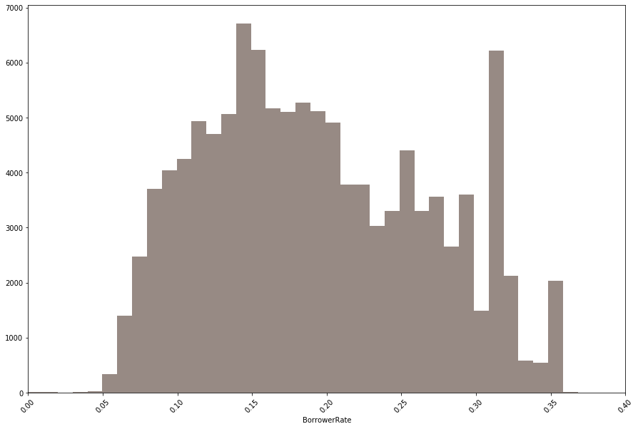

```python
# plot
plt.figure(figsize = (15, 10))
sns.distplot(borrower['BorrowerRate'], kde = False, hist_kws = {'alpha' : 1}, color = base_color,
             bins = 50);
plt.xticks(rotation=45);
# limit view
plt.xlim(0, .4);
```

The borrower rate histogram is slightly right-skewed, implying that the mean is larger than the median. However, there are also unexpected spikes for rates of approximately 0.25, 0.32, and 0.35. I wonder what may be driving these rates?

### Employment

I will now explore information pertaining to borrowers' employment status.

```python
borrower.Occupation.value_counts()[:10]
```

```
Other                       28617
Professional                13628
Computer Programmer          4478
Executive                    4311
Teacher                      3759
Administrative Assistant     3688
Analyst                      3602
Sales - Commission           3446
Accountant/CPA               3233
Clerical                     3164
Name: Occupation, dtype: int64
```

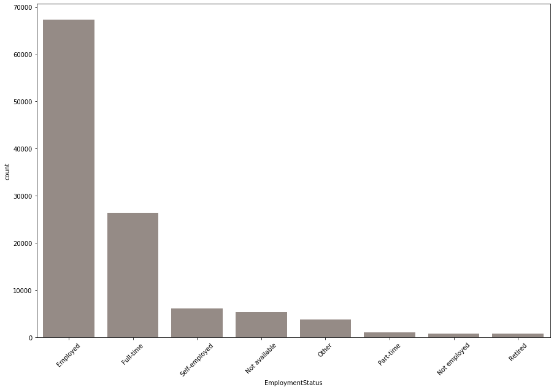

```python
# set order
emp_freq = borrower.EmploymentStatus.value_counts()
emp_freq = emp_freq.index

# plot
plt.figure(figsize = (15, 10))
sns.countplot(data = borrower, x ='EmploymentStatus', color = base_color, order = emp_freq);
plt.xticks(rotation=45);
```

It would be helpful if all the types of employment (e.g. full time, self employed, etc.) were consolidated into one. I will also remove the rows were the employment status is unavailable.

```python
# drop rows
borrower.drop(borrower[borrower.EmploymentStatus == 'Not available'].index, inplace=True)
```

```python
# confirm removal
borrower.loc[borrower.EmploymentStatus == 'Not available']
```

|  | ListingKey | BorrowerRate | Occupation | EmploymentStatus | EmploymentStatusDuration | IsBorrowerHomeowner | CreditScoreRangeLower | CreditScoreRangeUpper | CurrentCreditLines | OpenCreditLines | DebtToIncomeRatio | IncomeRange | IncomeVerifiable | StatedMonthlyIncome |
| --- | --- | --- | --- | --- | --- | --- | --- | --- | --- | --- | --- | --- | --- | --- |

```python
# combine employment status categories
to_replace = ['Full-time', 'Self-employed', 'Part-time']
borrower['EmploymentStatus'] = borrower.EmploymentStatus.str.replace(r'|'.join(to_replace), 'Employed')
```

```python
# confirm removal
borrower.loc[borrower.EmploymentStatus.isin(to_replace)]
```

|  | ListingKey | BorrowerRate | Occupation | EmploymentStatus | EmploymentStatusDuration | IsBorrowerHomeowner | CreditScoreRangeLower | CreditScoreRangeUpper | CurrentCreditLines | OpenCreditLines | DebtToIncomeRatio | IncomeRange | IncomeVerifiable | StatedMonthlyIncome |
| --- | --- | --- | --- | --- | --- | --- | --- | --- | --- | --- | --- | --- | --- | --- |

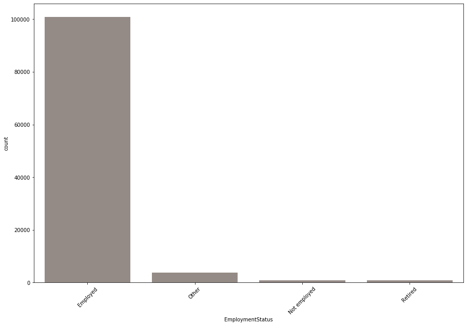

```python
# set order
new_emp_freq = borrower.EmploymentStatus.value_counts()
new_emp_freq = new_emp_freq.index

# plot
plt.figure(figsize = (15, 10))
sns.countplot(data = borrower, x ='EmploymentStatus', color = base_color, order = new_emp_freq);
plt.xticks(rotation=45);
```

Given that so many of the borrowers are employed, I will narrow my focus to only those borrowers.

```python
borrower = borrower.loc[borrower.EmploymentStatus == 'Employed']
```

Before looking at the employment duration column, I will first transform the "EmploymentStatusDuration" column from months to years.

```python
borrower['EmploymentStatusDurationYears'] = borrower['EmploymentStatusDuration']/12
borrower.drop(columns='EmploymentStatusDuration', inplace=True)
```

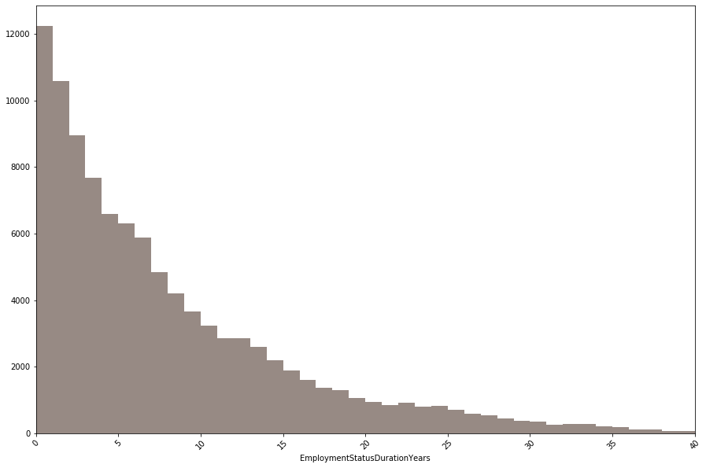

```python
# set bins
empdur_bin_edges = np.arange(0, borrower['EmploymentStatusDurationYears'].max()+1, 1)

# plot
plt.figure(figsize = (15, 10))
sns.distplot(borrower['EmploymentStatusDurationYears'], kde = False, hist_kws = {'alpha' : 1},
            color = base_color, bins = empdur_bin_edges);
plt.xticks(rotation=45)
plt.xlim(0, 40);
```

Due to the shape of the histogram, this data most likely requires a logarithmic transformation.

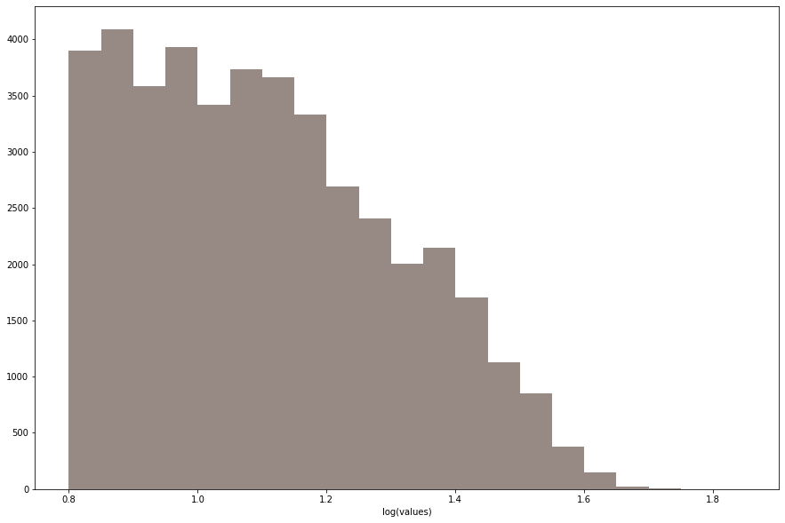

```python
# plot
plt.figure(figsize = (15, 10))
emp_log_data = np.log10(borrower['EmploymentStatusDurationYears'])
log_bin_edges = np.arange(0.8, emp_log_data.max()+0.1, .05)
plt.hist(emp_log_data, bins = log_bin_edges)
plt.xlabel('log(values)');
```

It appears that the employment duration data does not follow a log-normal distribution. Moving forward with my analysis, I have not decided to incorporate this variable.

Given that the largest amount of borrower occupations were categorized as "other", the Occupation column may not provide as much useful information as I originally hoped. The vast majority of borrowers are employed - this appears to be a characteristic investors favor. The employment duration histogram is heavily right-skewed.

### Homeownership

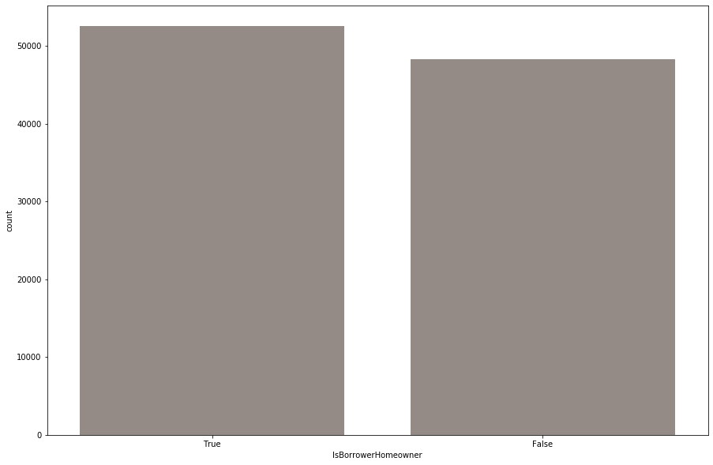

```python
# set order
home = [True, False]

# plot
plt.figure(figsize = (15, 10))
sns.countplot(data = borrower, x ='IsBorrowerHomeowner', color = base_color, order = home);
```

The amount of borrowers who do and do not own homes is nearly equally divided, with a slightly larger amount of borrowers owning homes. In another analysis, it would be interesting to delve deeper into the applicant's listing category - I wonder what percentage of non-homeowners are applying for housing loans?

### Credit

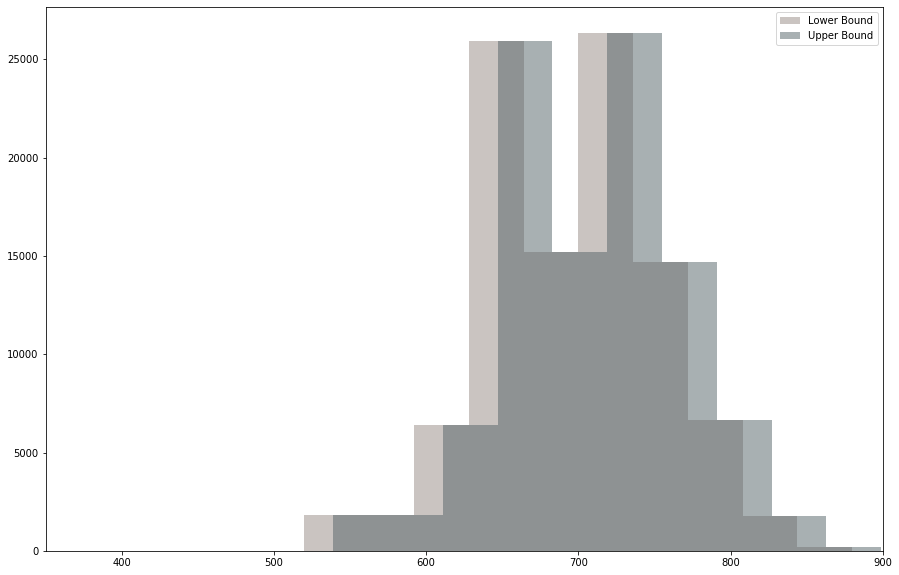

```python
# plot
plt.figure(figsize = (15, 10))
plt.hist(x = borrower['CreditScoreRangeLower'], alpha = 0.5, label = 'Lower Bound')
plt.hist(x = borrower['CreditScoreRangeUpper'], alpha = 0.5, label = 'Upper Bound')
plt.xlim(350, 900)
plt.legend(loc='upper right')
plt.show();
```

Moving forward with my analysis, I will use the lower bound of the credit score to serve as a proxy for the actual score. This is a more conservative approach than selecting the upper bound.

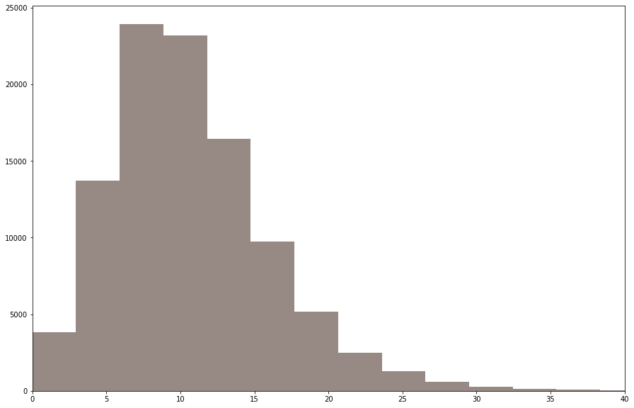

```python
# plot
plt.figure(figsize = (15, 10))
plt.hist(borrower['CurrentCreditLines'], color = base_color, bins = 20);
# limit view
plt.xlim(0, 40);
```

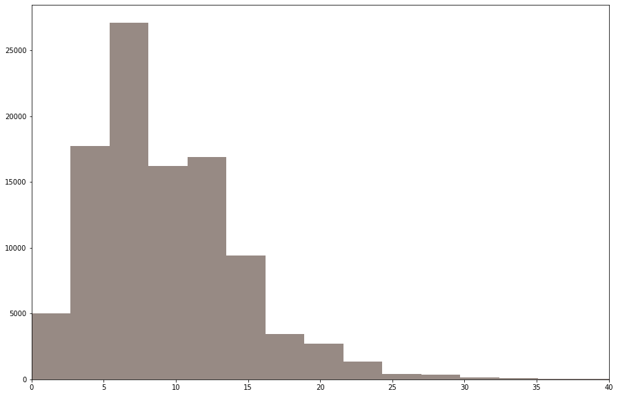

```python
# plot
plt.figure(figsize = (15, 10))
plt.hist(borrower['OpenCreditLines'], color = base_color, bins = 20);
# limit view
plt.xlim(0, 40);
```

### Income

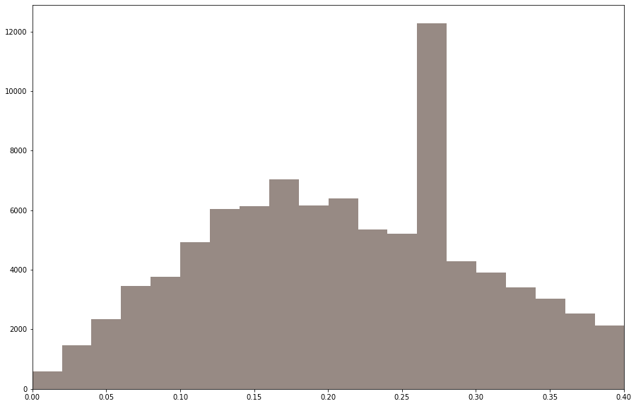

```python
# plot
plt.figure(figsize = (15, 10))
plt.hist(borrower['DebtToIncomeRatio'], color = base_color, bins = 500)
# limit view
plt.xlim(0, .4);
```

This debt-to-income ratio distribution is heavily skewed to the right, with a large spike around 0.3. I already noticed that this variable also had a lot of outliers. I will use a boxplot to explore these in more detail.

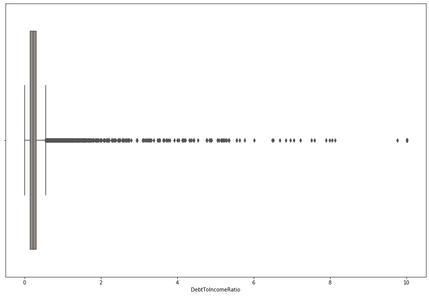

```python
# plot
plt.figure(figsize = (15, 10))
sns.boxplot(borrower['DebtToIncomeRatio'], color = base_color);
```

As expected, this box plot reveals a LOT of outliers in my debt-to-income ratio column. Before deciding whether or how many outliers to remove, I will use a violin plot to take a closer look at the distribution.

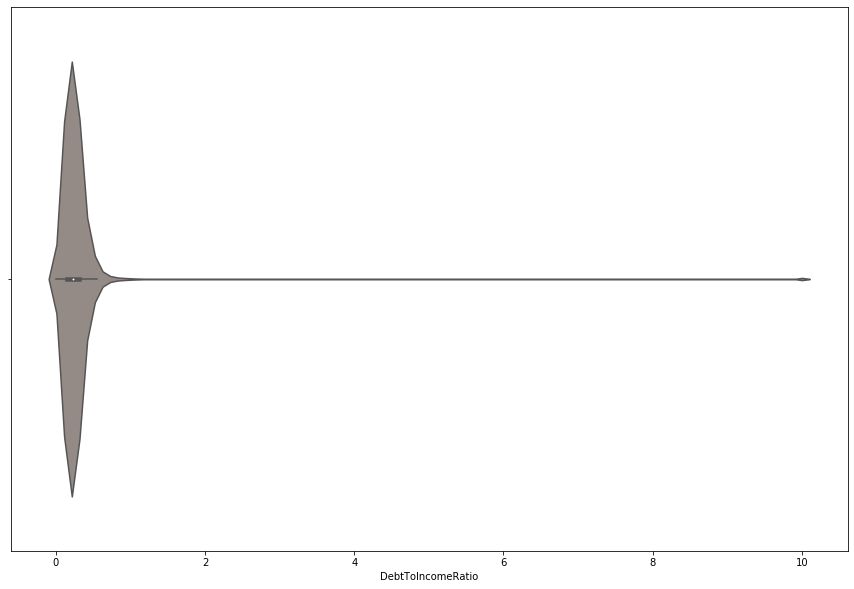

```python
# plot
plt.figure(figsize = (15, 10))
sns.violinplot(borrower['DebtToIncomeRatio'], color = base_color);
```

The violinplot reinforces what was seen in both the histogram and box plot - the distribution follows an almost normal distribution until about 1.5 but also has a long trail of outliers.

```python
borrower.loc[borrower.DebtToIncomeRatio > 1]['ListingKey'].count()
```

```
557
```

Given the size of my dataframe and the fact that only 557 entries have a debt-to-income ratio greater than 1, I think it is safe to drop at least some of my outliers. To be conservative, I will only remove those outliers where the ratio is greater than 1.5.

```python
borrower.drop(borrower[borrower.DebtToIncomeRatio > 1.5].index, inplace=True)
```

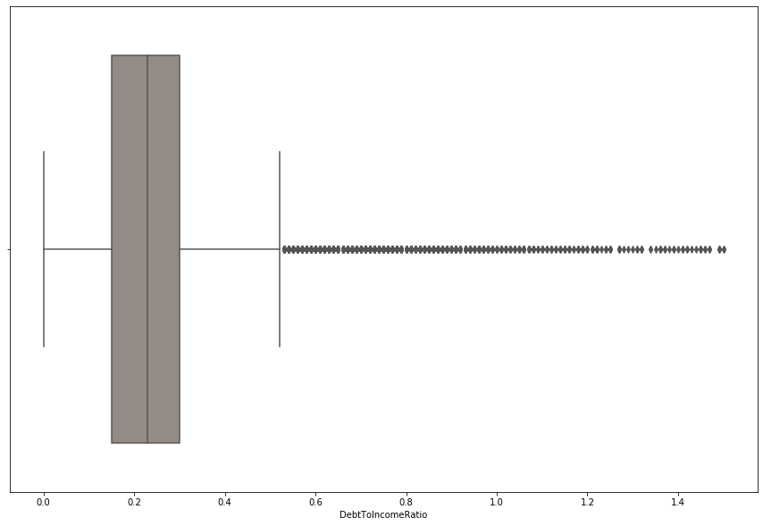

```python
# plot
plt.figure(figsize = (15, 10))
sns.boxplot(borrower['DebtToIncomeRatio'], color = base_color);
```

While this dataset still contains a lot of outliers, it is not as extreme as before.

Before plotting the Income Range column, I want to see how many of these incomes were verifiable.

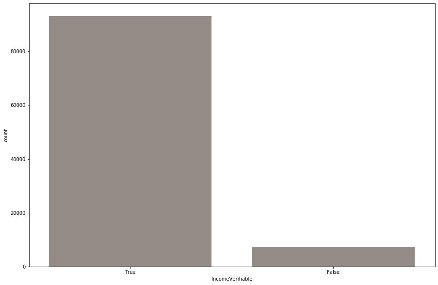

```python
# set order
ver = [True, False]

# plot
plt.figure(figsize = (15, 10))
sns.countplot(data = borrower, x ='IncomeVerifiable', color = base_color, order = ver);
```

Luckily, the vast majority of the incomes are verifiable. I will now remove the borrowers with unverifiable incomes before continuing with my analysis. Additionally, I will also remove will first remove the "Not displayed" values.

```python
# remove unverifiable incomes
borrower.drop(borrower[borrower.IncomeVerifiable == False].index, inplace=True)

# drop column value
borrower.drop(borrower[borrower.IncomeRange == 'Not displayed'].index, inplace=True)
```

```python
# confirm values removed
borrower.loc[borrower.IncomeVerifiable == False]
```

|  | ListingKey | BorrowerRate | Occupation | EmploymentStatus | IsBorrowerHomeowner | CreditScoreRangeLower | CreditScoreRangeUpper | CurrentCreditLines | OpenCreditLines | DebtToIncomeRatio | IncomeRange | IncomeVerifiable | StatedMonthlyIncome | EmploymentStatusDurationYears |
| --- | --- | --- | --- | --- | --- | --- | --- | --- | --- | --- | --- | --- | --- | --- |

```python
borrower.loc[borrower.IncomeRange == 'Not displayed']
```

|  | ListingKey | BorrowerRate | Occupation | EmploymentStatus | IsBorrowerHomeowner | CreditScoreRangeLower | CreditScoreRangeUpper | CurrentCreditLines | OpenCreditLines | DebtToIncomeRatio | IncomeRange | IncomeVerifiable | StatedMonthlyIncome | EmploymentStatusDurationYears |
| --- | --- | --- | --- | --- | --- | --- | --- | --- | --- | --- | --- | --- | --- | --- |

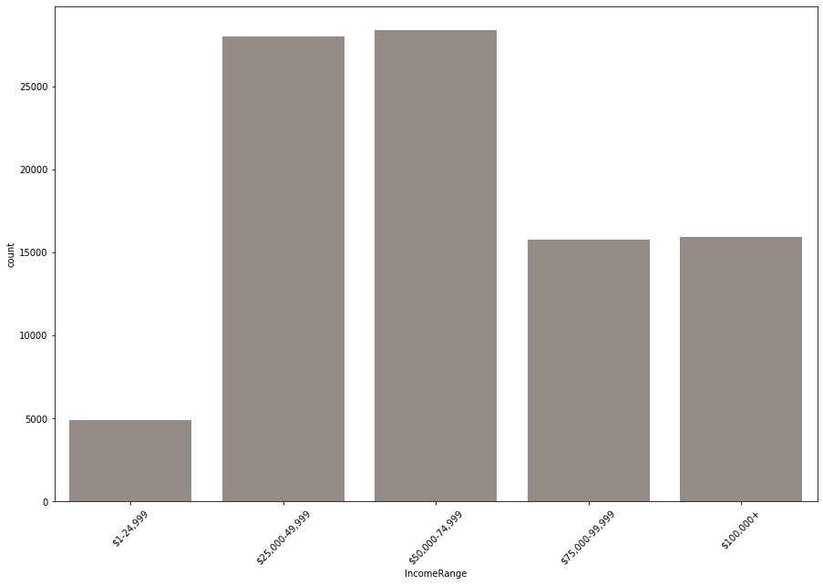

```python
# set order
inc = ['$1-24,999', '$25,000-49,999', '$50,000-74,999', '$75,000-99,999', '$100,000+']

# plot
plt.figure(figsize = (15, 10))
sns.countplot(data = borrower, x ='IncomeRange', color = base_color, order = inc);
plt.xticks(rotation=45);
```

```python
# drop rows
borrower.drop(borrower[borrower.IncomeRange == '$0'].index, inplace=True)
```

```python
# confirm removal
borrower.loc[borrower.IncomeRange == '$0']
```

|  | ListingKey | BorrowerRate | Occupation | EmploymentStatus | IsBorrowerHomeowner | CreditScoreRangeLower | CreditScoreRangeUpper | CurrentCreditLines | OpenCreditLines | DebtToIncomeRatio | IncomeRange | IncomeVerifiable | StatedMonthlyIncome | EmploymentStatusDurationYears |
| --- | --- | --- | --- | --- | --- | --- | --- | --- | --- | --- | --- | --- | --- | --- |

### Univariate Exploration Summary

The borrower rate, my main feature of interest, proved to have the most surprising distribution - almost bimodal in nature, with high spikes for rates around 0.25, 0.32 and 0.35 percent.

Nearly all borrowers are employed in some form, with a heavily right-skewed employment duration distribution. I chose to remove all rows where the employment status was unavailable, as well as combined all the types of employment into one category. I also transformed the duration variable from monthly to yearly duration. I used a log transformation on the employment duration distribution, but the data does not appear to be log-normal. Given my interest in borrowers' economic conditions, I think there are other variables - such as income range - that are better suited to my analysis, so I will not continue to explore further transformations on the employment duration variable.

The debt-to-income ratio is also heavily right-skewed, with most borrowers having debt-to-income ratios less than 0.30. Due to the large amount of outliers, I chose to remove any ratio over 1.5.

The credit score distribution was slightly left-skewed, with the dataset representing more borrowers with better credit.

## Bivariate Exploration

To continue with my analysis, I will now explore the relationships between the borrower rate and the financial health variables. I will begin with a pair grid of the quantitative variables - the credit score, number of credit lines, and debt ratio. Due to the large amount of data, a random sample of 500 data points will be selected.

```python
borrower_sample = borrower.sample(500)
```

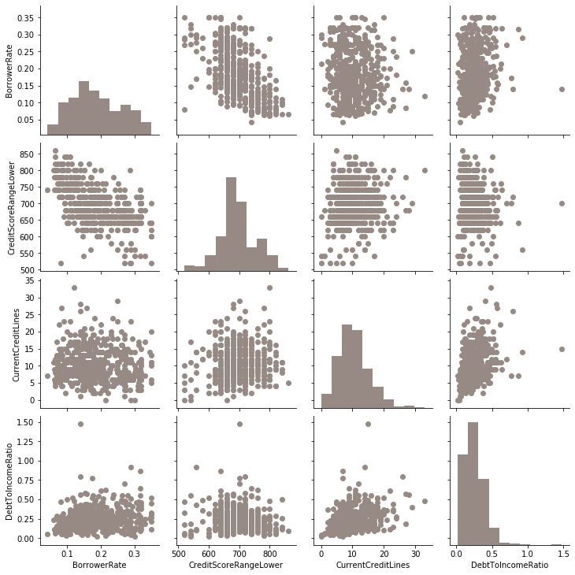

```python
g = sns.PairGrid(data = borrower_sample, vars = ['BorrowerRate','CreditScoreRangeLower',
                                                 'CurrentCreditLines', 'DebtToIncomeRatio'], palette = base_color);
g.map_diag(plt.hist);
g.map_offdiag(plt.scatter);
```

I can also use panda's .corr() function to look at the Pearson's correlation coefficient across these quantitative variables.

```python
# determine correlation
corr = borrower.corr(method='pearson', min_periods=1)
corr
```

|  | BorrowerRate | IsBorrowerHomeowner | CreditScoreRangeLower | CreditScoreRangeUpper | CurrentCreditLines | OpenCreditLines | DebtToIncomeRatio | IncomeVerifiable | StatedMonthlyIncome | EmploymentStatusDurationYears |
| --- | --- | --- | --- | --- | --- | --- | --- | --- | --- | --- |
| BorrowerRate | 1.000000 | -0.123281 | -0.526748 | -0.526748 | -0.081496 | -0.090636 | 0.175231 | NaN | -0.131484 | -0.009793 |
| IsBorrowerHomeowner | -0.123281 | 1.000000 | 0.300162 | 0.300162 | 0.271641 | 0.273296 | 0.017325 | NaN | 0.199202 | 0.180876 |
| CreditScoreRangeLower | -0.526748 | 0.300162 | 1.000000 | 1.000000 | 0.146583 | 0.153054 | -0.034300 | NaN | 0.152791 | 0.083478 |
| CreditScoreRangeUpper | -0.526748 | 0.300162 | 1.000000 | 1.000000 | 0.146583 | 0.153054 | -0.034300 | NaN | 0.152791 | 0.083478 |
| CurrentCreditLines | -0.081496 | 0.271641 | 0.146583 | 0.146583 | 1.000000 | 0.959480 | 0.362914 | NaN | 0.208095 | 0.141707 |
| OpenCreditLines | -0.090636 | 0.273296 | 0.153054 | 0.153054 | 0.959480 | 1.000000 | 0.363315 | NaN | 0.207031 | 0.140670 |
| DebtToIncomeRatio | 0.175231 | 0.017325 | -0.034300 | -0.034300 | 0.362914 | 0.363315 | 1.000000 | NaN | -0.224928 | 0.026409 |
| IncomeVerifiable | NaN | NaN | NaN | NaN | NaN | NaN | NaN | NaN | NaN | NaN |
| StatedMonthlyIncome | -0.131484 | 0.199202 | 0.152791 | 0.152791 | 0.208095 | 0.207031 | -0.224928 | NaN | 1.000000 | 0.095364 |
| EmploymentStatusDurationYears | -0.009793 | 0.180876 | 0.083478 | 0.083478 | 0.141707 | 0.140670 | 0.026409 | NaN | 0.095364 | 1.000000 |

Based on the results of the matrix and correlation calculations, I will further explore the credit-related quantitative variables (credit score and credit lines). I will also examine the categorical variables - homeownership and income range - in relation to borrower rate.

### Homeownership

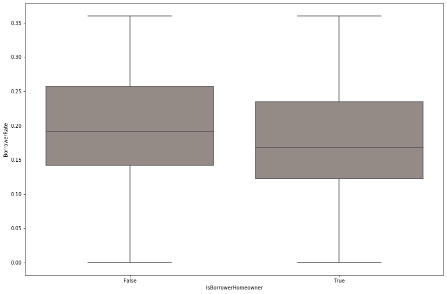

```python
# plot
plt.figure(figsize=(15,10));
sns.boxplot(data = borrower, x = 'IsBorrowerHomeowner' , y = 'BorrowerRate', color = base_color);
```

It appears that borrowers who are not homeowners receive on average higher borrower rates than homeowners.

### Credit

In the matrix, I observed the clearest linear relationship between credit score and borrower rate. I will now explore this in more detail with the full dataset.

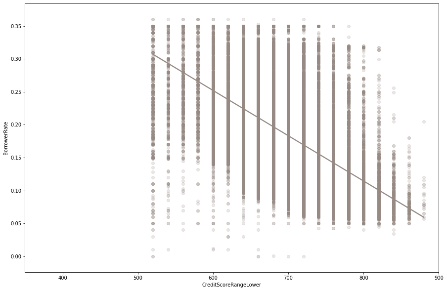

```python
plt.figure(figsize = (15, 10))
sns.regplot(data = borrower, x = 'CreditScoreRangeLower', y = 'BorrowerRate', color = base_color,
            scatter_kws = {'alpha': 0.2});
plt.xlim(350, 900);
```

From this scatterplot, I once again observe a negative relationship between borrower rate and credit score. This means borrowers with higher credit scores tend to enjoy lower interest rates than borrowers with lower scores. Let me look at the correlation coefficient between the credit score and borrower rate that I calculated above.

```python
# filter dataset
credit_corr = corr['CreditScoreRangeLower']

# view results
credit_corr[0]
```

```
-0.5267475990990893
```

As suspected when viewing the plot, there is a moderate negative relationship between the two variables. Surprisingly, there doesn't appear to be a similar relationship between the borrower rate and current credit lines. I would still like to further explore these two variables.

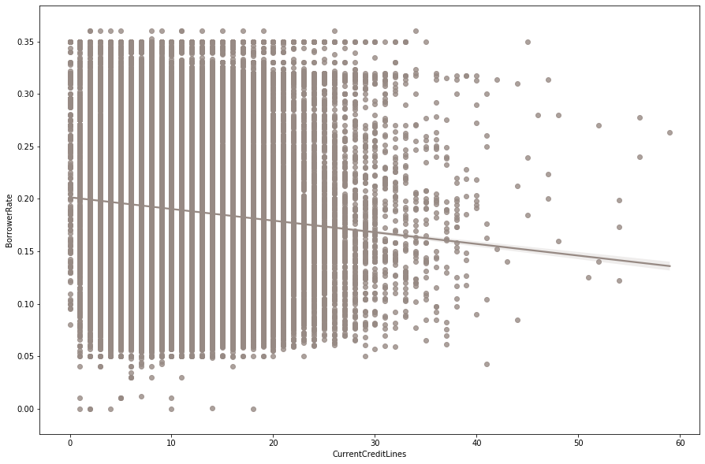

```python
# plot
plt.figure(figsize = (15, 10))
sns.regplot(data = borrower, x = 'CurrentCreditLines' , y = 'BorrowerRate', color = base_color);
```

There doesn't appear to be much of a relationship between the two variables, though the outliers may be pulling the fitted line more horizontally. I will create a second dataset without the outliers and plot again, out of curiosity.

```python
borrower_sm = borrower.loc[borrower.CurrentCreditLines < 40]
```

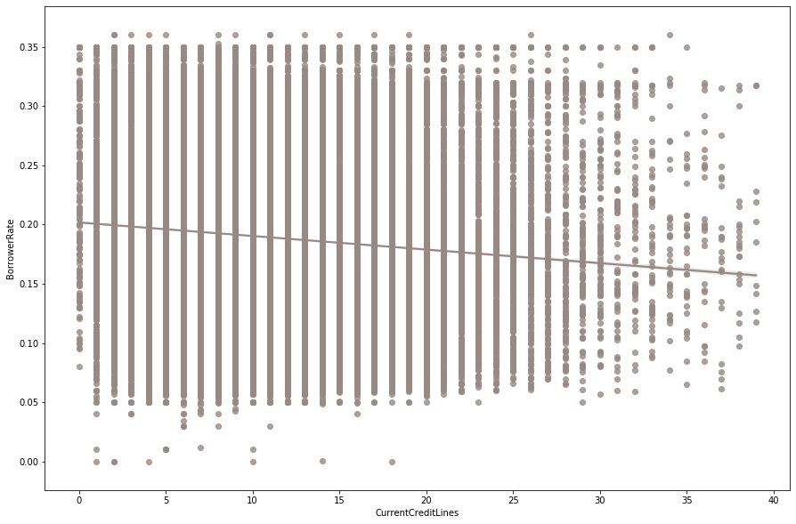

```python
# plot
plt.figure(figsize = (15, 10))
sns.regplot(data = borrower_sm, x = 'CurrentCreditLines' , y = 'BorrowerRate', color = base_color);
```

It looks like my guess was wrong - the line does not change after removing the most extreme outliers. I will check the Pearson's coefficient, using the original dataset and the "corr" object calculated above.

```python
# filter dataset
lines_corr = corr['CurrentCreditLines']

# view results
lines_corr
```

[output not shown]

As suspected, the coefficient is too small to indicate a meaningful relationship between the two variables. This is a very interesting observation, as it is commonly advised to open lines of credit to improve your credit score. Looking back to the pairplot, it looks like there may be a slightly positive relationship between credit score and lines of credit. I will quickly examine these variables in more detail.

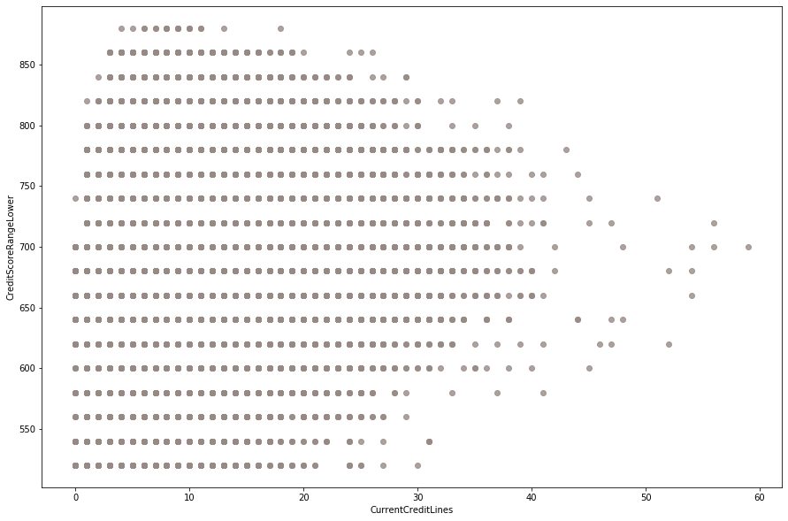

```python
# plot
plt.figure(figsize = (15, 10))
sns.regplot(data = borrower, x = 'CurrentCreditLines' , y = 'CreditScoreRangeLower', fit_reg = False,
            color = base_color);
```

There appears to be a weak nonlinear relationship between the two variables. I did also noticed a possible relationship between current credit lines and the debt-to-income ratio. I will explore this relationship below.

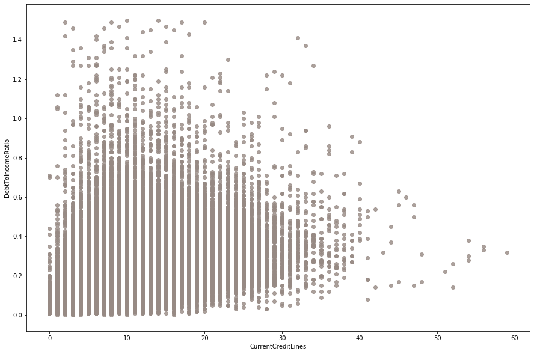

```python
# plot
plt.figure(figsize = (15, 10))
sns.regplot(data = borrower, x = 'CurrentCreditLines' , y = 'DebtToIncomeRatio', fit_reg = False,
            color = base_color);
```

```python
# filter dataset
lines_corr = corr['CurrentCreditLines']

# view results
lines_corr[6]
```

```
0.36291404265021865
```

Looking at the Pearson's coefficient, I see a weak but positive relationship between the two variables.

### Income

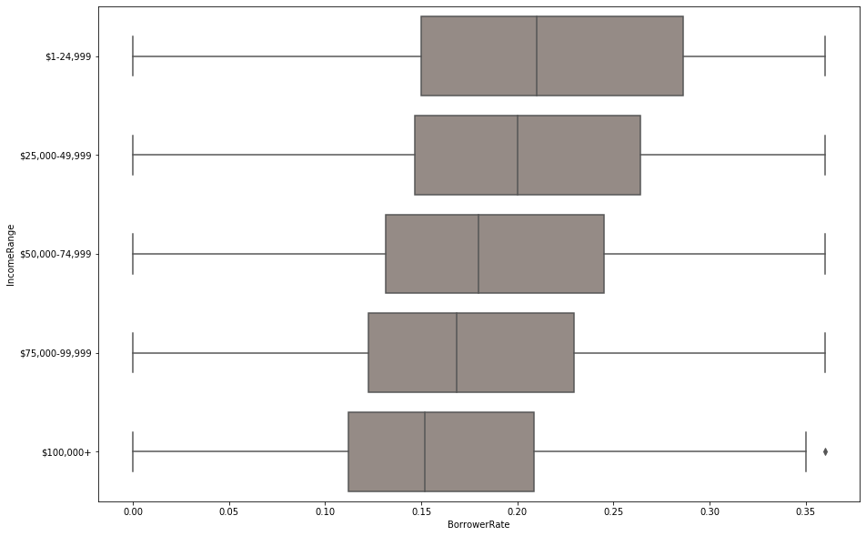

```python
# plot
plt.figure(figsize=(15,10));
sns.boxplot(data = borrower, x = 'BorrowerRate', y = 'IncomeRange', color = base_color, order = inc);
```

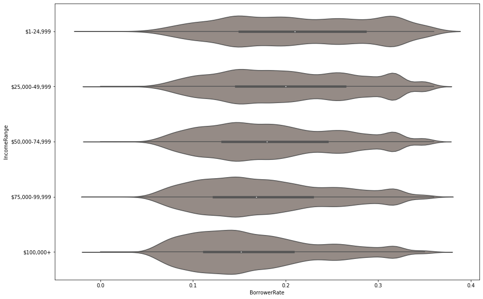

```python
plt.figure(figsize = (15, 10))
sns.violinplot(data = borrower, x = 'BorrowerRate', y = 'IncomeRange', color = base_color, order = inc);
```

### Bivariate Exploration Summary

I observed the clearest relationship between the borrower rate and credit score, where borrowers with higher credit scores tend to enjoy lower interest rates than borrowers with lower scores. Surprisingly, a similar relationship did not exist between the borrower rate and number of lines of credit. However, a weak positive relationship was observed between lines of credit and the debt-to-income ratio. Borrowers in higher income ranges received on average lower rates, as did borrowers who owned homes.

## Multivariate Exploration

For the multivariate exploration, I am curious if the moderate negative relationship observed between borrower rate and credit score is affected by selected financial health variables (homeownership, number of credit lines, debt-to-income ratio, and income range).

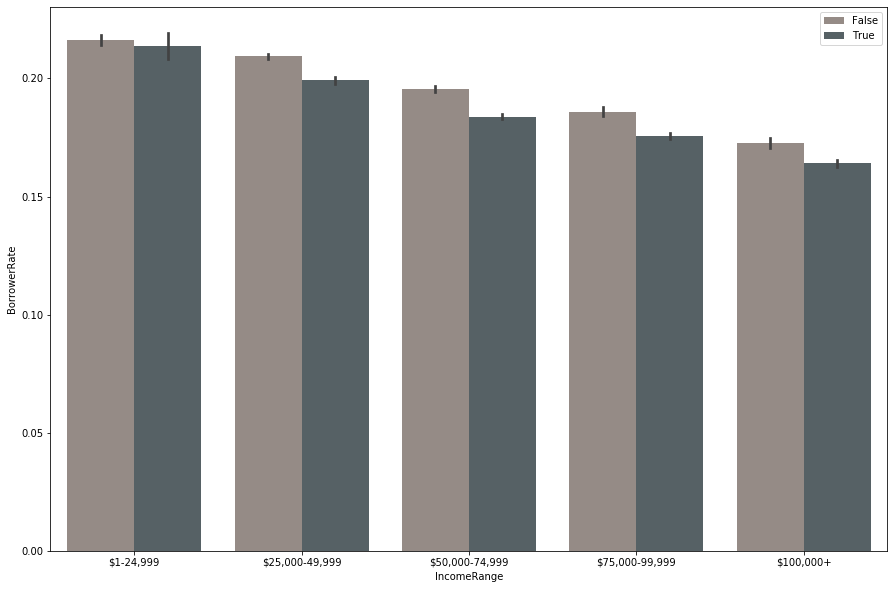

```python
# plot
plt.figure(figsize=(15, 10))
ax = sns.barplot(data = borrower, x = 'IncomeRange', y = 'BorrowerRate', hue = 'IsBorrowerHomeowner',
                 order = inc)
plt.legend(loc='upper_right');
```

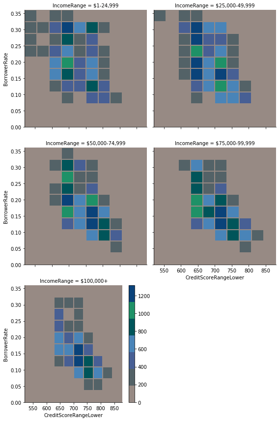

```python
# specify color palette
my_cmap = ListedColormap(sns.color_palette().as_hex())

# plot
g = sns.FacetGrid(data = borrower, col = 'IncomeRange', col_wrap = 2, size = 4,
                margin_titles = True, col_order = inc)
g.map(plt.hist2d, 'CreditScoreRangeLower', 'BorrowerRate', cmap = my_cmap);
plt.colorbar();
```

The negative relationship between credit score and borrower rate holds across all income ranges, with borrowers earning between 50,000 and under 75,000 USD seeing the strongest association.

I am curious to see how the borrower rate and credit score variables interact with lines of credit. To analyze this, I will first bucket the lines of credit into categories.

```python
# View the min, 25%, 50%, 75%, max credit line values
borrower['CurrentCreditLines'].describe()
```

```
count    93024.000000
mean        10.429276
std          5.456485
min          0.000000
25%          7.000000
50%         10.000000
75%         13.000000
max         59.000000
Name: CurrentCreditLines, dtype: float64
```

```python
# assign bin edges
credit_bin_edges = [-1, 7, 10, 13, 59]

# labels for credit lines
credit_bin_names = ['Low', 'Medium', 'Moderately High', 'High']

# create column
borrower['CreditLineBins'] = pd.cut(borrower['CurrentCreditLines'], credit_bin_edges,
                                    labels=credit_bin_names)

# check for column
borrower.sample(5)
```

[output not shown]

Now I can use the CreditLineBins column as a categorical variable in my heatplot matrix.

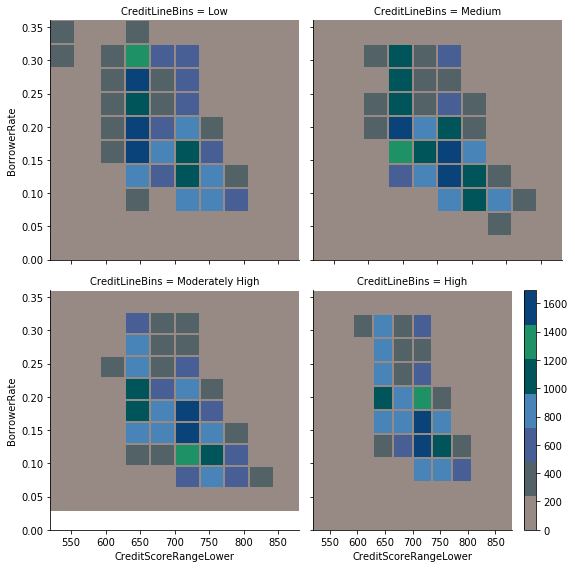

```python
# plot
g = sns.FacetGrid(data = borrower, col = 'CreditLineBins', col_wrap = 2, size = 4,
                margin_titles = True, col_order = credit_bin_names)
g.map(plt.hist2d, 'CreditScoreRangeLower', 'BorrowerRate', cmap = my_cmap);
plt.colorbar();
```

Like with income levels, similar negative relationships between credit score and borrower rate appear across credit lines. Those with moderately high amounts of credit see the strongest negative relationship, implying that opening more lines of credit can help a borrower receive a lower rate if their credit score is also high.

### Multivariate Exploration Summary

The negative relationship between borrower rate and credit score can be enhanced by other financial features, such as the borrower's homeowner status, number of credit lines, and income. However, lower earners (under 50,000 USD) experience a weaker relationship than higher earners.

```python
# export final dataframe for explanatory analysis
borrower.to_csv(r'borrower_info.csv', index=False)
```